# report

Martin

May 11, 2017

# Formatting

The first thing we want to do – after reading in the data – is formatting. That’ll make things consistent and easier for computations & comparisons along the way.

```r
setwd("C:/Users/martDawg/Desktop")
library(ggplot2)
library(plotly)
# read the data
df <- read.csv('homework_example_data.csv', header=TRUE, stringsAsFactors = FALSE)
names(df) <- gsub('.', '', names(df), fixed = TRUE)
# cleaning some column data
df$XNewSessions <- gsub('%', '', df$XNewSessions, fixed = TRUE)
df$EcommerceConversionRate <- gsub('%', '', df$EcommerceConversionRate, fixed=TRUE)
df$BounceRate <- gsub('%', '', df$BounceRate, fixed=TRUE)
df$EcommerceConversionRate <- as.numeric(df$EcommerceConversionRate)
df$XNewSessions <- as.numeric(df$XNewSessions)
df$EcommerceConversionRate <- as.numeric(df$EcommerceConversionRate)
df$BounceRate <- as.numeric(df$BounceRate)
df$Medium <- gsub(' ', '', df$Medium, fixed=TRUE)
# Standardize format of Avg Session Duration
df$AvgSessionDuration <- ifelse(nchar(df$AvgSessionDuration) == 7,
                                df$AvgSessionDuration,
                                substr(df$AvgSessionDuration, 3, nchar(df$AvgSessionDuration)))
# Derive session minutes column
df$AvgSessionMinutes <- as.numeric(substr(df$AvgSessionDuration, 3,4))+
    as.numeric(substr(df$AvgSessionDuration, 6,7))/60
```

## The Objective

We want to measure the effectiveness of our marketing campaign. We have some Google Analytics data – ie Source, Medium, & Converson Rate – for all our traffic sources.

What we’re starting with:

| Source | Medium | XNewSessions | Users | BounceRate | PagesSession | AvgSessionDuration | EcommerceConversionRate | Transactions | AvgSessionMinutes |
| --- | --- | --- | --- | --- | --- | --- | --- | --- | --- |
| google | organic | 63.00 | 4346892 | 42.36 | 2.86 | 0:02:04 | 0.38 | 16435.00 | 2.066667 |
| (direct) | (none) | 72.39 | 2317005 | 40.83 | 3.02 | 0:01:50 | 0.72 | 16599.00 | 1.833333 |
| facebook | cpc | 85.17 | 1148220 | 75.11 | 1.49 | 0:00:30 | 0.43 | 4989.00 | 0.500000 |
| m.facebook.com | referral | 88.17 | 393453 | 55.15 | 1.91 | 0:00:57 | 0.75 | 2954.04 | 0.950000 |
| l.instagram.com | referral | 84.70 | 349047 | 53.91 | 2.19 | 0:00:51 | 0.08 | 296.64 | 0.850000 |

### Looking at Transactions

Since our stated primary objective is transactions we’ll focus on Mediums that had transactions.

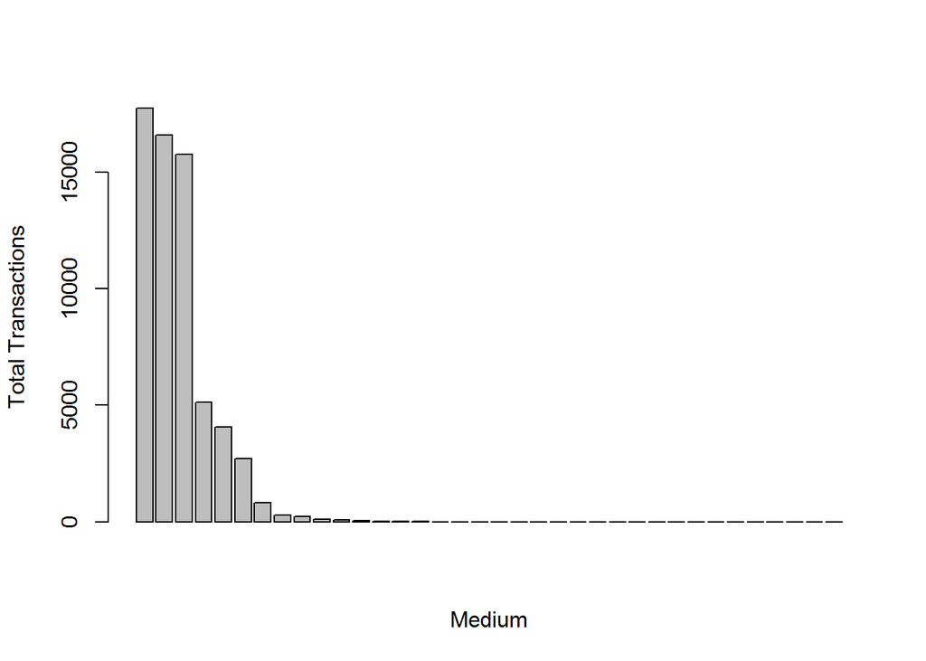

```r
library(plyr)
med <-ddply(df, ~Medium, summarise, tot_transactions = sum(Transactions))
med <-med[order(med$tot_transactions, decreasing=TRUE),]
rownames(med) <- 1:nrow(med)
med_lst <- med[1:12, "Medium"]
barplot(med$tot_transactions, xlab="Medium", ylab = "Total Transactions")
```

#

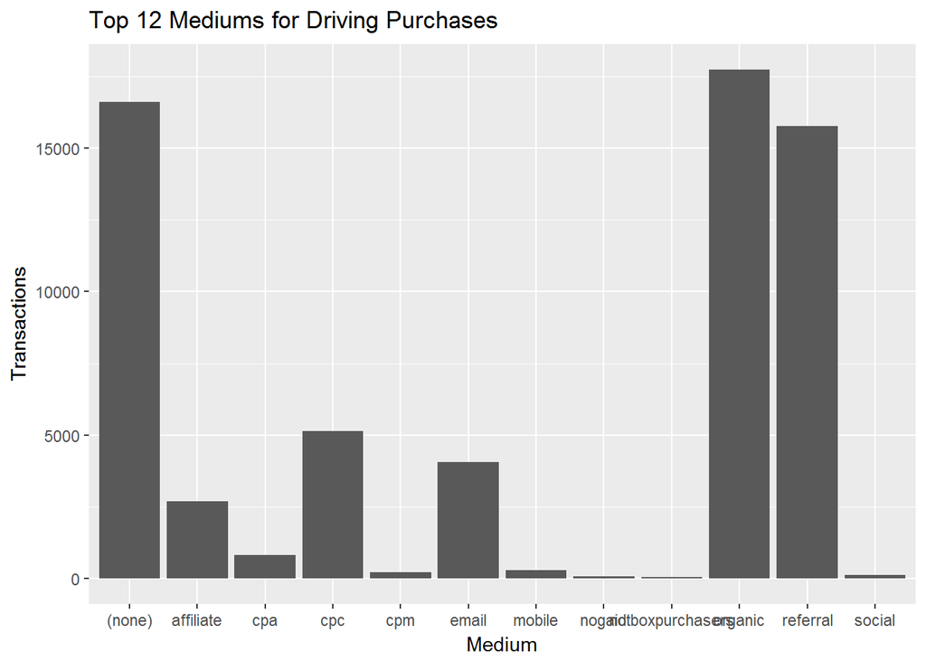

```r
df2 <- filter(df, Medium %in% med_lst)
ggplot(df2, aes(x=Medium, y=Transactions))+geom_bar(stat="identity")+
  labs(title="Top 12 Mediums for Driving Purchases")
```

With this subset, let’s dig deeper into the trasactions. Until now we’ve only looked at aggregate – ie total – transactions. But that’s only part of the story: To optimize our marketing dollars we need to know the success rate as well.

Specifically, we’ll look at the relationship between conversion rate and session time for each medium. To make the relationship more clear, we’ll remove campaigns with no transactions.

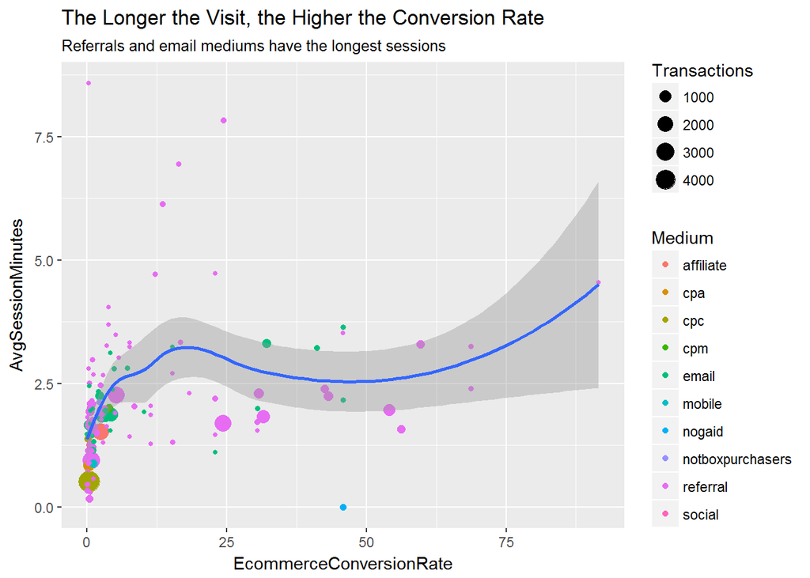

```r
trans <- filter(df2, Transactions>0, Medium != "(none)", Medium != "organic")
g<-ggplot(trans, aes(x=EcommerceConversionRate, y=AvgSessionMinutes))+geom_jitter(aes(color=Medium, size=Transactions))+
    labs(title="The Longer the Visit, the Higher the Conversion Rate",
         subtitle="Referrals and email mediums have the longest sessions") +geom_smooth()
g
```

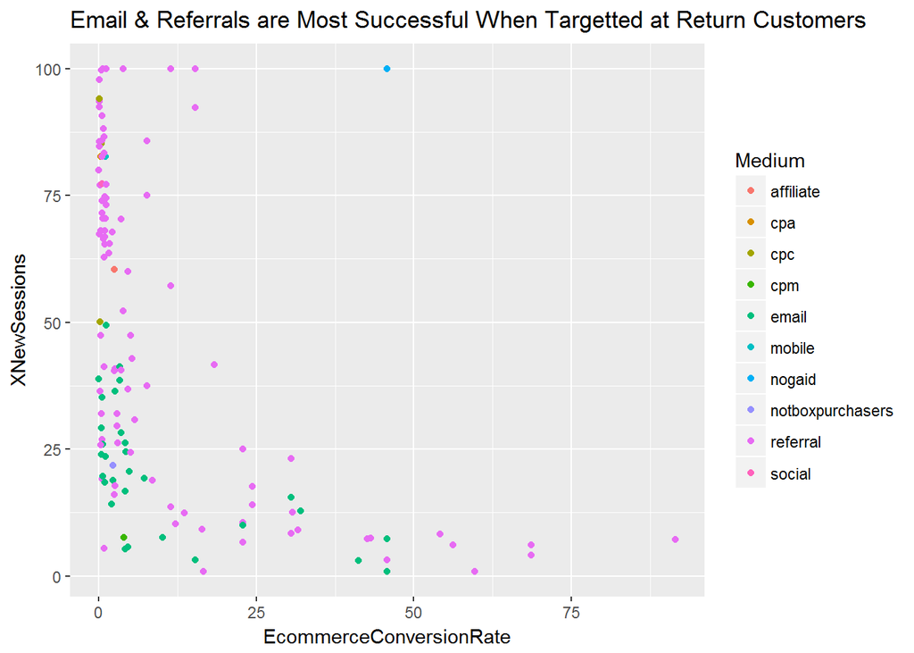

```r
ggplot(trans, aes(EcommerceConversionRate, XNewSessions))+geom_jitter(aes(colour=Medium))+
    labs(title="Email & Referrals are Most Successful When Targetted at Return Customers")
```

```r
email<- filter(df, Medium == 'email')
ref <- filter(df, Medium == 'referral', AvgSessionMinutes <10)
best_ref_sources <- ref[order(ref$EcommerceConversionRate, decreasing=TRUE),][1:10, c("Source", "EcommerceConversionRate","Medium", "Transactions")]
best_email_sources <- email[order(email$EcommerceConversionRate, decreasing=TRUE),][1:10,c("Source", "EcommerceConversionRate","Medium", "Transactions")]
kable(best_ref_sources, caption="Top Referral Sources")
```

Top Referral Sources

|  | Source | EcommerceConversionRate | Medium | Transactions |
| --- | --- | --- | --- | --- |
| 721 | alphaoutpost.dev-oceanxacsf.acsitefactory.com | 91.56 | referral | 8.24 |
| 407 | savevy.com | 68.67 | referral | 24.72 |
| 546 | couponhunter.us | 68.67 | referral | 12.36 |
| 112 | mmi.transerainc.net | 59.71 | referral | 247.20 |
| 97 | couponsock.com | 56.22 | referral | 288.40 |
| 54 | dealscove.com | 54.14 | referral | 1013.52 |
| 823 | demo.dev-oceanxacsf.acsitefactory.com | 45.78 | referral | 4.12 |
| 73 | hotdeals.com | 43.19 | referral | 412.00 |
| 96 | couponvario.com | 42.62 | referral | 222.48 |
| 36 | promopro.com | 31.59 | referral | 1293.68 |

```r
kable(best_email_sources, caption="Top Email Sources")
```

Top Email Sources

|  | Source | EcommerceConversionRate | Medium | Transactions |
| --- | --- | --- | --- | --- |
| 53 | not bff | 45.78 | email | 24.72 |
| 58 | interested in beauty | 45.78 | email | 12.36 |
| 47 | welcome | 41.20 | email | 37.08 |
| 14 | klaviyo | 32.08 | email | 366.68 |
| 51 | winback | 30.52 | email | 24.72 |
| 65 | Non-purchasers (in the last year) | 22.89 | email | 4.12 |
| 59 | Interested in Beauty | 15.26 | email | 4.12 |
| 48 | beautycon la - tickets (follow up everyone) | 10.17 | email | 8.24 |
| 27 | 1. Welcome | 7.23 | email | 24.72 |
| 28 | cancelled 8.24 | 4.82 | email | 16.48 |

## Findings & Recommendations

We saw there are clear relationships between the medium used for a campaign and the success rate of a campaign. The amount of time users spend on the site is also a key factor in driving success.

Some obvious recommendations include

1. Focusing time and money on email and referral campaigns, especially with successful sources like Kaviyo and dealscove.com
2. Email & Referral campaings should be targetted heavilly toward past customers.